# Assignment 11: DNA methylation and enrichment analysis

Lukas Häuser

```r
set.seed(40) # Fix seed for reproducibility
```

Get Bisulfite-sequencing data:

```r
bs <- readRDS("./w11_practical/bs.rds")

MatrixGenerics::rowRanges(bs)
```

```
## GRanges object with 578097 ranges and 0 metadata columns:
##            seqnames    ranges strand
##               <Rle> <IRanges>  <Rle>
##        [1]    chr22  16050097      *
##        [2]    chr22  16050114      *
##        [3]    chr22  16050174      *
##        [4]    chr22  16050206      *
##        [5]    chr22  16050213      *
##        ...      ...       ...    ...
##   [578093]    chr22  51244314      *
##   [578094]    chr22  51244503      *
##   [578095]    chr22  51244509      *
##   [578096]    chr22  51244532      *
##   [578097]    chr22  51244561      *
##   -------
##   seqinfo: 2 sequences from an unspecified genome; no seqlengths
```

```r
Biobase::pData(bs)
```

```
## DataFrame with 6 rows and 2 columns
##           Type        Pair
##    <character> <character>
## C1      cancer       pair1
## C2      cancer       pair2
## C3      cancer       pair3
## N1      normal       pair1
## N2      normal       pair2
## N3      normal       pair3
```

Get annotations (hs):

```r
# genes
ah <- AnnotationHub::AnnotationHub()
ensdb <- ah[["AH109336"]]
```

```
## loading from cache
```

```
## require("ensembldb")
```

```r
chr22 <-  GRanges(seqnames=Rle(c("22")),
                  ranges = IRanges(1, end=50818468))
genesChr22 <- genes(ensdb, columns=c("gene_seq_start", "gene_seq_end", "gene_name"),
                    filter=GRangesFilter(chr22))
seqlevelsStyle(genesChr22) <- "UCSC"
```

Obtain the coordinates of the genes within the top 5 DMRs.

```r
dmrRanges <- readRDS("./w11_practical/dmr.rds")

dmrRanges <- dmrRanges[order(abs(dmrRanges$meandiff), decreasing=TRUE)]
dmrRangesGenes <- dmrRanges[!is.na(dmrRanges$overlapping.genes)]

# Get the genes within Differentially methylated regions
topIdx <- order(dmrRangesGenes$min_smoothed_fdr)[1:5] # get top 5 DMR regions
genesDmr <- unlist(data.table::tstrsplit(dmrRangesGenes[topIdx]$overlapping.genes, split=", "))
genesDmr <- genesDmr[!is.na(genesDmr)]
dmrGenes.top <- genesChr22[genesChr22$gene_name %in% genesDmr]
dmrGenes.top
```

```
## GRanges object with 7 ranges and 2 metadata columns:
##                   seqnames            ranges strand |   gene_name
##                      <Rle>         <IRanges>  <Rle> | <character>
##   ENSG00000093009    chr22 19479457-19520612      + |       CDC45
##   ENSG00000138964    chr22 44172956-44219533      + |       PARVG
##   ENSG00000138944    chr22 44243665-44312951      - |     SHISAL1
##   ENSG00000077942    chr22 45502238-45601135      + |       FBLN1
##   ENSG00000130943    chr22 46255663-46263343      - |      PKDREJ
##   ENSG00000100416    chr22 46330875-46357340      + |        TRMU
##   ENSG00000075275    chr22 46360834-46537620      - |      CELSR1
##                           gene_id
##                       <character>
##   ENSG00000093009 ENSG00000093009
##   ENSG00000138964 ENSG00000138964
##   ENSG00000138944 ENSG00000138944
##   ENSG00000077942 ENSG00000077942
##   ENSG00000130943 ENSG00000130943
##   ENSG00000100416 ENSG00000100416
##   ENSG00000075275 ENSG00000075275
##   -------
##   seqinfo: 1 sequence from hg38 genome
```

```r
# Get all
genesDmr <- unlist(data.table::tstrsplit(dmrRangesGenes$overlapping.genes, split=", "))
genesDmr <- genesDmr[!is.na(genesDmr)]
dmrGenes.all <- genesChr22[genesChr22$gene_name %in% genesDmr]
dmrGenes.all
```

```
## GRanges object with 655 ranges and 2 metadata columns:
##                   seqnames            ranges strand |   gene_name
##                      <Rle>         <IRanges>  <Rle> | <character>
##   ENSG00000220248    chr22 16857619-16860718      - |     ZNF402P
##   ENSG00000237438    chr22 17044873-17047426      + |       CECR7
##   ENSG00000177663    chr22 17084954-17115693      + |      IL17RA
##           LRG_355    chr22 17084959-17115694      + |      IL17RA
##   ENSG00000235478    chr22 17121530-17132105      + |   LINC01664
##               ...      ...               ...    ... .         ...
##   ENSG00000212569    chr22 50669804-50669901      + |       Y_RNA
##   ENSG00000251322    chr22 50674415-50733212      + |      SHANK3
##   ENSG00000100312    chr22 50738196-50745339      + |         ACR
##   ENSG00000079974    chr22 50767501-50783667      - |      RABL2B
##   ENSG00000184319    chr22 50798655-50799123      + |   RPL23AP82
##                           gene_id
##                       <character>
##   ENSG00000220248 ENSG00000220248
##   ENSG00000237438 ENSG00000237438
##   ENSG00000177663 ENSG00000177663
##           LRG_355         LRG_355
##   ENSG00000235478 ENSG00000235478
##               ...             ...
##   ENSG00000212569 ENSG00000212569
##   ENSG00000251322 ENSG00000251322
##   ENSG00000100312 ENSG00000100312
##   ENSG00000079974 ENSG00000079974
##   ENSG00000184319 ENSG00000184319
##   -------
##   seqinfo: 1 sequence from hg38 genome
```

Retrieve metyhlation levels and visualize:

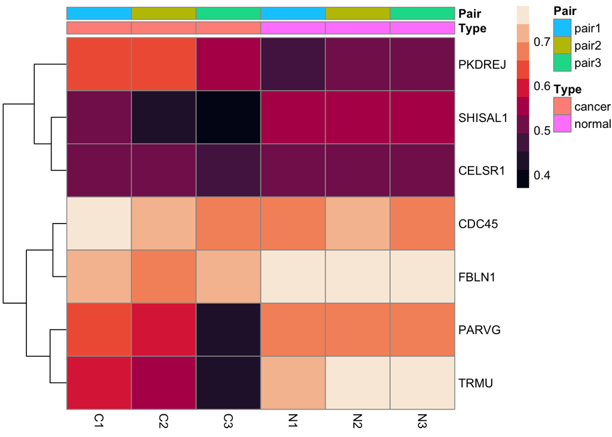

```r
metPr <- bsseq::getMeth(bs,
                        regions=dmrGenes.top,
                        what="perRegion")
colnames(metPr) <- colnames(bs)
rownames(metPr) <- dmrGenes.top$gene_name
metPr <- metPr[!is.na(rowSums(metPr)),]

annotationCol <- as.data.frame(pData(bs))
rownames(annotationCol) <- colnames(metPr)
pheatmap::pheatmap(metPr,
                   cluster_rows=TRUE,
                   cluster_cols=FALSE,
                   annotation_col=annotationCol,
                   show_rownames = TRUE,
                   color=viridis::rocket(10))
```

Enrichment analysis of all genes within DMRs agaist all genes on chr22:

```r
res <- rGREAT::great(dmrGenes.all, gene_sets="GO:BP", tss_source="hg38", background=genesChr22, cores=6)
```

```
## * TSS source: TxDb.
```

```
## * check whether TxDb package 'TxDb.Hsapiens.UCSC.hg38.knownGene' is installed.
```

```
## * gene ID type in the extended TSS is 'Entrez Gene ID'.
```

```
## * restrict chromosomes to 'chr1, chr2, chr3, chr4, chr5, chr6, chr7, chr8, chr9, chr10,
##     chr11, chr12, chr13, chr14, chr15, chr16, chr17, chr18, chr19, chr20, chr21, chr22, chrX,
##     chrY, chrM'.
```

```
## * 18100/30601 protein-coding genes left.
```

```
## * update seqinfo to the selected chromosomes.
```

```
## * TSS extension mode is 'basalPlusExt'.
```

```
## * construct the basal domains by extending 5000bp to upstream and 1000bp to downsteram of TSS.
```

```
## * calculate distances to neighbour regions.
```

```
## * extend to both sides until reaching the neighbour genes or to the maximal extension.
```

```
## * use GO:BP ontology with 15517 gene sets (source: org.Hs.eg.db).
```

```
## * check gene ID type in `gene_sets` and in `extended_tss`.
```

```
## * use self-defined background regions.
```

```
## * remove excluded regions from background.
```

```
## * overlap `gr` to background regions (based on midpoint).
```

```
## * in total 644 `gr`.
```

```
## * overlap extended TSS to background regions.
```

```
## * check which genes are in the gene sets.
```

```
## * only take gene sets with size >= 5.
```

```
## * in total 987 gene sets.
```

```
## * overlap `gr` to every extended TSS.
```

```
## * perform binomial test for each biological term.
```

```r
bp <- rGREAT::getEnrichmentTables(res)
bp.significant <- bp[bp$p_adjust < 0.05,] # filter for significance with p<5%
bp.significant
```

```
##            id
## 1  GO:0044273
## 2  GO:0046456
## 3  GO:0006690
## 4  GO:0002250
## 5  GO:0002460
## 6  GO:0006575
## 7  GO:0042219
## 8  GO:0044272
## 9  GO:1901568
## 10 GO:1901570
## 11 GO:0006790
## 12 GO:0016053
## 13 GO:0046394
## 14 GO:0019752
```

[output cut: 330 more lines]

Enrichment analysis of genes within top5 DMRs agaist all genes on chr22 (just because we thought that might be interesting too):

```r
res <- rGREAT::great(dmrGenes.top, gene_sets="GO:BP", tss_source="hg38", background=genesChr22, cores=6)
```

```
## * TSS source: TxDb.
```

```
## * extended_tss is already cached, directly use it.
```

```
## * use GO:BP ontology with 15517 gene sets (source: org.Hs.eg.db).
```

```
## * check gene ID type in `gene_sets` and in `extended_tss`.
```

```
## * use self-defined background regions.
```

```
## * remove excluded regions from background.
```

```
## * overlap `gr` to background regions (based on midpoint).
```

```
## * in total 7 `gr`.
```

```
## * overlap extended TSS to background regions.
```

```
## * check which genes are in the gene sets.
```

```
## * only take gene sets with size >= 5.
```

```
## * in total 987 gene sets.
```

```
## * overlap `gr` to every extended TSS.
```

```
## * perform binomial test for each biological term.
```

```r
bp <- rGREAT::getEnrichmentTables(res)
bp.significant <- bp[bp$p_adjust < 0.05,] # filter for significance with p<5%
bp.significant
```

```
##           id   description genome_fraction observed_region_hits fold_enrichment
## 1 GO:0007155 cell adhesion       0.1191566                    6        7.193414
##        p_value     p_adjust mean_tss_dist observed_gene_hits gene_set_size
## 1 1.798948e-05 0.0001079369         81251                  4            29
##   fold_enrichment_hyper p_value_hyper p_adjust_hyper
## 1              5.613793   0.003262723     0.01957634
```

# Results

We identified the 5 regions with highest differential methylation. These 5 regions contain 7 genes (CDC45, PARVG, SHISAL1, FBLN1, PKDREJ, TRMU, CELSR1). We did enrichment analyses of all genes within DRMs against all genes of chr22 and of the 7 genes within the top5 DRMS. Then we retrieved the methylation levels of these 7 genes. With a significance of `p_adust<5%`, we found 68 enriched gene sets within DRMs on chr22. The highest fold enrichment of these gene sets is about 5.2 between the normal and cancer cases. In the the genes within the top 5 DRMs only a single gene set was found with a particularly high fold enrichment of approximately 7.2. Thus, it seems like the cancer case could be associated with high fold enrichment of highly diffirentially methylated regions.